# Manchester City Transfer Options

22/09/2021

## Brief

- Manchester City want to improve in the January transfer window.
- They don’t want to add more than one player, as Pep Guardiola fears adding more could upset the balance of his team.
- They want a proven talent as they can’t afford anything but a top two finish this season and are not confident in doing so with their current squad.
- Where should they invest their money?

## Who are Manchester City?

- Football team founded in 1894
- Highly successful club competing in the Premier League
- Rapidly improved since being bought over by the Abu Dhabi United Group in 2008
- Only team to ever reach the 100 point mark in the Premier League
- Evaluated by Forbes at $2.69 billion
- Finished 1st in the Premier League just last year

## Approach to tackling the brief?

- Planned how I was going to meet their request
- Collected Appropriate data
- Cleaned the Data
- Looked at where Manchester City were statistically weakest
- Looked for Players to Strengthen their Weakness(ses)

## Preemptive Jargon Bust - What is xG?

xG (Expected goals) is a predictive model used to assess every goal-scoring chance, and the likelihood a player will score. An xG model computes, for each chance, the probability to score based on what we know about the outcome of similar chances.

- e.g a Penalty kick has an xG of 0.79
- a shot from the halfway line would have a very low xG
- It’s very important that xG is interpreted correctly for it to have any kind of meaning

## Manchester City Strength and Weakness identification

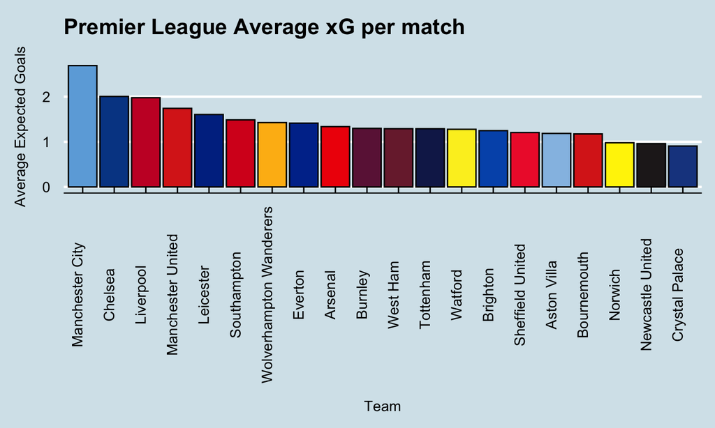

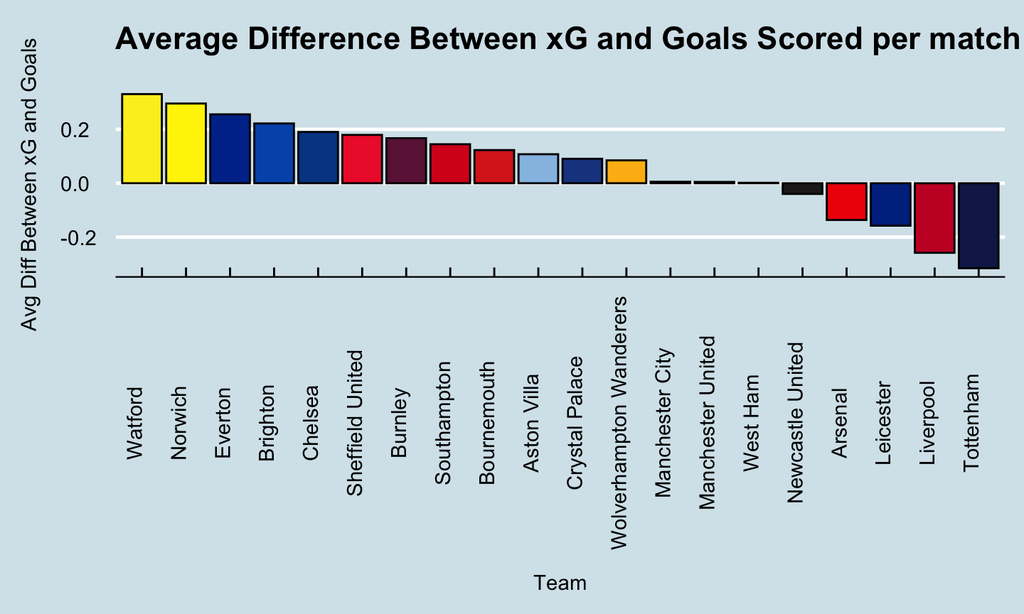

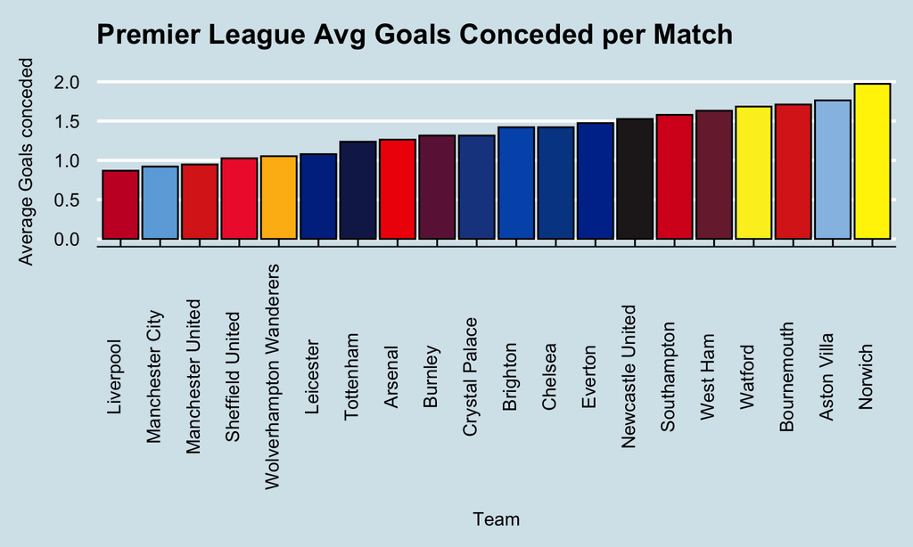

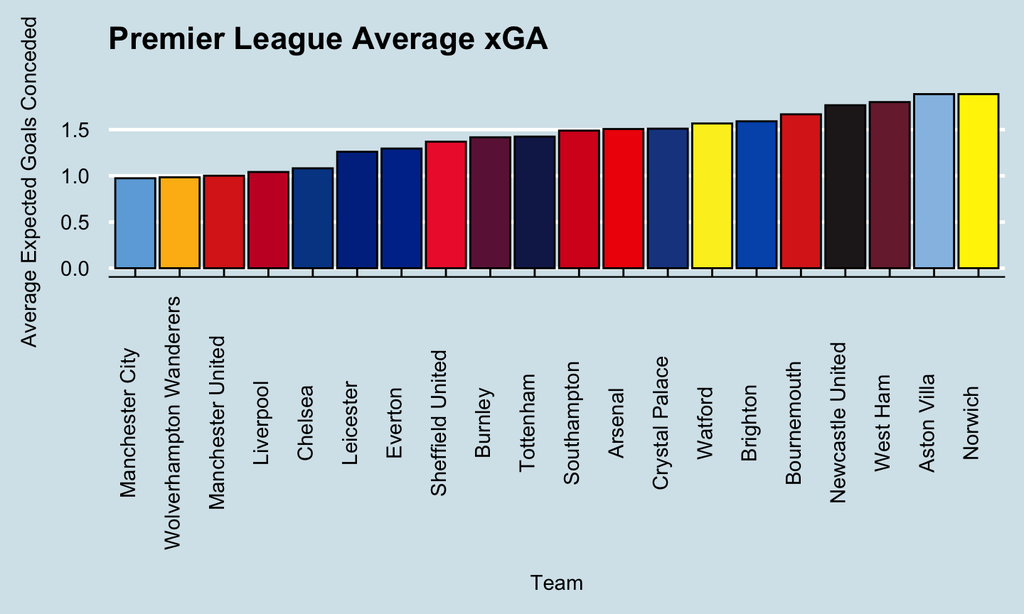

## Conclusion

- They create plenty chances to score
- They rarely concede, and have one of the best defenses in the league
- They don’t have a great expected goal vs goal scored rate for a team of their calibre
- This suggests they should invest in a clinical forward

## How do you define whether a forward is ‘clinical’ or not?

- They score goals (lots of goals)
- They perform at a high level
- They outperform their xG

## Who are the best strikers in Europe?

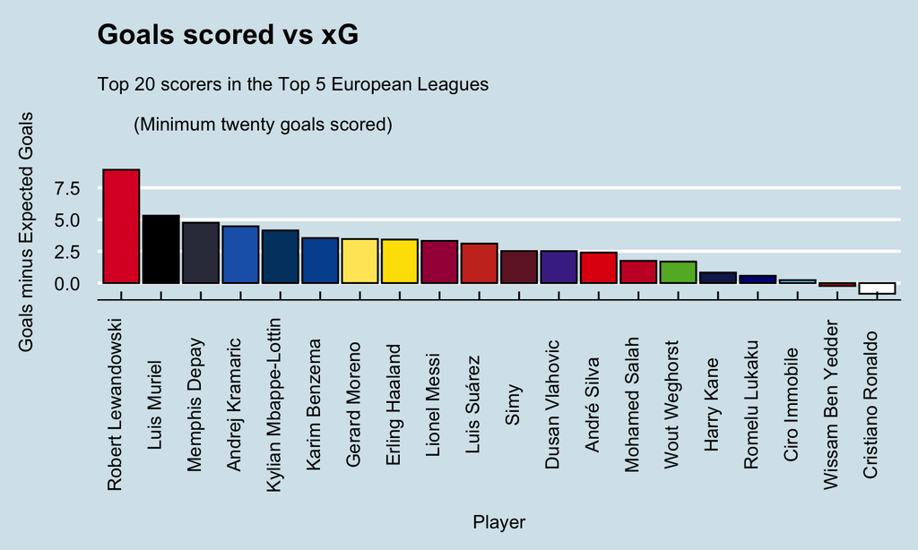

## Lessons for the future

- Getting open source Football Data is very hard
- Hex codes are infuriating
- Everything will always takes longer than you think
- Don’t use a presentation tool you’ve never used before (especially if it’s ioslides)